# Untitled

YongJunYang

2019년 3월 2일

### **목차**

#### 1. 프로젝트 개요

#### 2. 데이터 수집

#### 3. 텍스트 마이닝 프로세스

#### 4. 토픽 모델링, LDA

#### 5. 추천시스템 및 결론

## **1. 프로젝트 개요**

### 방대한 데이터들 속에서 유용한 정보를 얻기 위한 분석 방법 중 대표적으로 데이터 마이닝(Data mining)이 있다. 우리는 데이터 마이닝 중 비정형 데이터를 이용한 텍스트 마이닝을 하기로 하였다.

### 영화시장에서는 일반적으로 사람들이 영화를 선택할 때, 네티즌들의 리뷰가 영화를 선택하는데 많은 영향을 미치고 있다. 즉, 네티즌들은 영화를 보기 전 관객들의 반응을 미리 확인하여 조금 더 만족할만한 영화를 선택하여 관람한다.

### 이번 프로젝트의 목적은 <왓챠플레이> 영화 리뷰를 통해 ’토픽 모델링(LDA)’을 하여 기존 27개의 대분류의 장르를 세분화하는 것이다. 또한, 유저들의 리뷰 단어를 통해 세분화한 장르가 얼만큼 분류가 잘 되었는지 확인해보았다. 이를 통해 왓챠플레이의 기존 추천 알고리즘과 다른 유저들의 감성 기반으로 한 알고리즘을 추천시스템으로 만들었다.

## **2. 데이터 수집**

### 사용된 데이터 포털 사이트 : 왓챠 플레이

### 데이터 수집 방법 : 웹 크롤링

### 데이터 형태 및 방식 : JSON 형태의 GET 방식

### 데이터 : 영화이름 / 유저닉네임 / 리뷰 / 별점 / 좋아요 / 생년월일 / 성별 / 작성날짜 / 유저신뢰도 / 팔로워 (총 10개 컬럼)

### 세부 내용 : 총 27개의 장르, 영화 장르별 리뷰 수의 3분위수, 별점 4.5점 이상

### Library 불러오기

```r
library(tidyverse)
library(rJava)
library(NLP4kec)
library(tm)
library(topicmodels)
library(LDAvis)
library(servr)
library(readr)
library(slam)
library(RcppMeCab)
library(Rmpfr)
```

### Web Crawling 자동화

```r
# user-agent 미리 생성
myUA <- 'Mozilla/5.0 (Windows NT 10.0; Win64; x64) AppleWebKit/537.36 (KHTML, like Gecko) Chrome/72.0.3626.96 Safari/537.36'

# 빈 데이터 프레임 생성
result <- data.frame()

# 영화 리뷰 수집 함수
collect_review <- function(genre) {
  for(i in 0:20) {
    if(i == 0) { #처음 20개를 불러오기 위해서는 query에 page가 필요 없습니다
      res_1 <- GET(url = 'https://play.watcha.net/category.json',
                   query = list(genre = genre,
                                sort = '2'),
                   user_agent(agent = myUA))
    } else { # 그 이외 페이지는 query에 page가 필요해서 넣어주었습니다
      res_1 <- GET(url = 'https://play.watcha.net/category.json',
                   query = list(genre = genre,
                                sort = '2',
                                page = i),
                   user_agent(agent = myUA))
    }

    cat('##############################\n')
    cat('# 영화 이름, 영화 코드 수집시도 # \n')
    cat('##############################\n')

    tryCatch({
      json <- res_1 %>% content(as = 'text') %>% fromJSON()

      # 영화이름, 영화코드 수집 후 데이터 프레임 생성
      movie_name <- json$categories$title
      movie_code <- json$categories$code
      movie <- data.frame(movie_name, movie_code)
      # factor형으로 되어있기 때문에 character형으로 변경
      movie$movie_name <- as.character(movie$movie_name)
      movie$movie_code <- as.character(movie$movie_code)
      num <- 0
    }, error = function(e) cat('-> 에러가 발생했습니다!\n') )

    # movie의 2번째 열 코드를 for문에 넣어서 각 영화 리뷰가 10만건 이상인지 확인
    for(j in movie[, 2]) {
      num <- num + 1

      res_2 <- GET(url = str_c('https://play.watcha.net/contents/',j,'.json'),
                   user_agent(agent = myUA))

      cat('영화 이름 : (', movie[num, 1],') 수집중 \n')

      tryCatch({
        json2 <- res_2 %>% content(as = 'text') %>% fromJSON

        # 별점 평가한 인원 파악
        count <- json2$ratings_count

        # 해당 영화 인원이 10만 이하면 그냥 건너 뛰고 다음 for문을 이어서 진행합니다
        if(count < 22292) next

      }, error = function(e) cat('-> 에러가 발생했습니다!\n'))

      # 10만건 이상인 영화의 댓글을 수집합니다
      for(k in 1:1000) {
        res_3 <- GET(url = str_c('https://play.watcha.net/contents/',j,'/comments.json'),
                     query = list(page = k),
                     user_agent(agent = myUA))

        tryCatch({
          json3_prev <- res_3 %>% content(as = 'text', encoding = 'UTF-8') %>% fromJSON()
          json3_next <- json3_prev$comments

          # 댓글이 없으면 for문 종료
          if(is.null(json3_next$text)) break

          # 댓글이 있으면 수집
          movie_name <- movie$movie_name[num]
          review     <- json3_next$text
          likes      <- json3_next$likes_count
          user_name  <- json3_next$user$name
          rate       <- json3_next$user_action$rating
          birth      <- json3_next$user$birthday
          gender     <- json3_next$user$gender
          write      <- json3_next$user$created_at
          confidence <- json3_next$user$confidence
          follower   <- json3_next$user$followers_count
          result     <- rbind(result, data.frame(movie_name, user_name, review, rate, likes,
                                                 birth, gender, write, confidence, follower))

          cat('댓글 개수 10만개 이상 수집 시작 영화 이름 : (', movie[num, 1], ')', k, '번째 댓글 수집 완료\n')

        }, error = function(e) cat('-> 에러가 발생했습니다!\n'))

        Sys.sleep(0.5)
      }
    }
  }
  return(result) # 결과 반환
}
```

### 작업공간 설정하고 데이터 불러오기

```r
#setwd("~/Dropbox/personal/winter/MachineLearning/project/final_data/")
setwd('C:/Users/yyj94/Desktop/머신러닝 프로젝트')
Sys.setlocale('LC_ALL','C')
```

```
## [1] "C"
```

```r
load(file = 'result.RData')
str(result)
```

```
## 'data.frame':    338025 obs. of  10 variables:
##  $ movie_name: Factor w/ 1025 levels "왕좌의 게임 시즌 1",..: 1 1 1 1 1 1 1 1 1 1 ...
##  $ user_name : Factor w/ 84059 levels "배가현","제라드 정",..: 2 4 3 1 8 6 7 10 9 12 ...
##  $ review    : Factor w/ 1218016 levels "나 , 친구: 괜찮아! xxx는 무슨 일이 있어도 철왕좌에 앉게 될거야!!\n(썩둑)\n나, 친구: 으아아아아아아아아악!!!",..: 2 3 1 4 6 5 7 9 12 10 ...
##  $ rate      : num  5 4.5 5 5 5 5 4.5 4.5 4.5 5 ...
##  $ likes     : int  479 200 197 134 101 65 50 45 41 40 ...
##  $ birth     : Factor w/ 11094 levels "1980-01-08","1994-12-27",..: 4 1 3 2 5 7 8 9 12 10 ...
##  $ gender    : Factor w/ 3 levels "female","male",..: 2 3 2 1 3 2 2 2 2 2 ...
##  $ write     : Factor w/ 127251 levels "2013-01-15T10:09:08+09:00",..: 4 3 2 1 7 6 5 11 12 10 ...
##  $ confidence: int  2 2 1 1 2 2 1 2 2 2 ...
##  $ follower  : int  534 332 359 37 298 70 1861 693 560 502 ...
```

## **3. 텍스트 마이닝 프로세스**

### 텍스트 데이터 전처리 –> 형태소 분석 –> 말뭉치 생성 –> DTM 생성 –> 토픽 모델링

#### 텍스트 데이터 전처리

```r
# (1) 평점 4.5이상만 추출
result <- result %>%
  dplyr::filter(rate >= 4.5)

# (2) 열명 변경
rownames(result) <- seq(from = 1, to = nrow(result), by = 1)

# (3) review 타입 변경
result$review <- as.character(result$review)
```

#### EDA

##### 리뷰가 가장 많은 영화는?

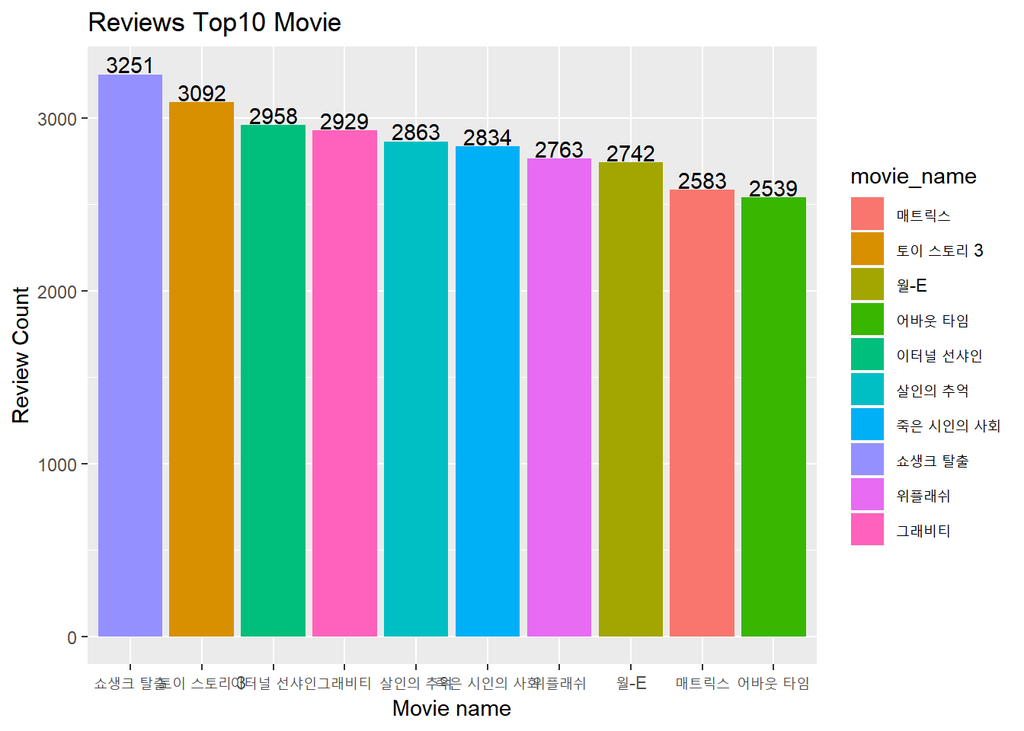

```r
result %>% group_by(movie_name) %>% summarise(n = n()) %>%
  arrange(desc(n)) %>% head(10) %>%
  ggplot(mapping = aes(x = reorder(movie_name, -n), y = n, fill = movie_name)) +
  geom_bar(stat = 'identity') +
  ggtitle('Reviews Top10 Movie') +
  geom_text(aes(label = n), vjust = -0.1) +
  xlab("Movie name") + ylab("Review Count")
```

#### 별점 5.0점이 가장 많은 영화는?

[figure not shown]

```r
result %>% filter(rate >= 5.0) %>% group_by(movie_name) %>% summarise(n = n()) %>%
  arrange(desc(n)) %>% head(10) %>%
  ggplot(mapping = aes(x = reorder(movie_name, -n), y = n, fill = movie_name)) +
  geom_bar(stat = 'identity') + xlab("Movie name") + ylab("Review Count") +
  ggtitle('Movies rated over 4.5?') +
  theme_light()
```

#### 영화에 별점 4.5점 이상 준 사람은 누구?

```r
# NA값 지우고, rate(별점)>= 4.5이상만 추출, 남녀 구분, 나이 구분.
# (10대이하~이상: 0, 20대이상:1, 30대이상: 2, 40대이상: 3, 50대이상: 4, 60대 이상 5, 6)

# NA값 제거
result_na_omited <- na.omit(result)
result_final <- result_na_omited

# 생년월일 계산해서 나이대 추출
birth <- str_sub(result_final$birth, 1, 4)
birth <- as.numeric(birth)


# 현재연도에서 생년월일 빼고 1더하기
result_final$age <- 2019 - birth + 1

result_final$age <- ifelse(result_final$age < 20, 10,
                          ifelse(result_final$age < 30, 20,
                             ifelse(result_final$age < 40, 30,
                                    ifelse(result_final$age < 50, 40,
                                           ifelse(result_final$age < 60, 50,
                                                  ifelse(result_final$age < 70, 60, 70))))))

# 나이대를 factor로 만들어주기
result_final$age <- as.factor(result_final$age)
```

#### 성별 나이별 시각화

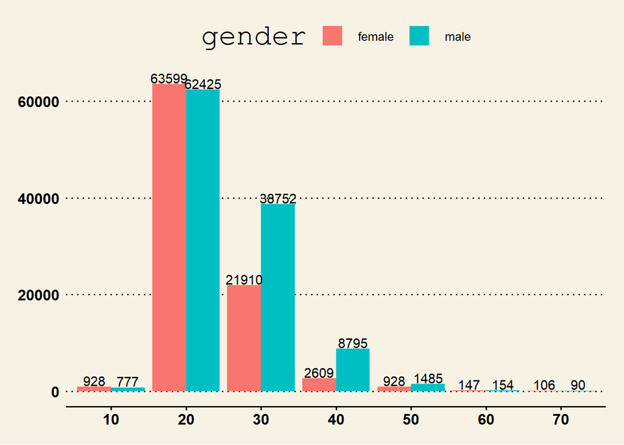

```r
# result에서 NA값 제거된 데이터 프레임에서  rate 4점이상, not_set지우고, 성별/나이를 그룹화해서 summarise로 집계하기.
result_final %>%
  dplyr::filter(gender != 'not_set', rate >= 4.5) %>%
  group_by(gender, age) %>%
  summarise(n = n()) %>%
  ggplot(mapping = aes(x = age, y = n, fill = gender)) +
  geom_bar(stat= 'identity', position = 'dodge') +
  geom_text(aes(label = n), position = position_dodge(width = 0.9), vjust = -0.1) +
  ggthemes::theme_wsj()
```

#### 영화에 별점 4.5점 이상 준 사람의 연령대

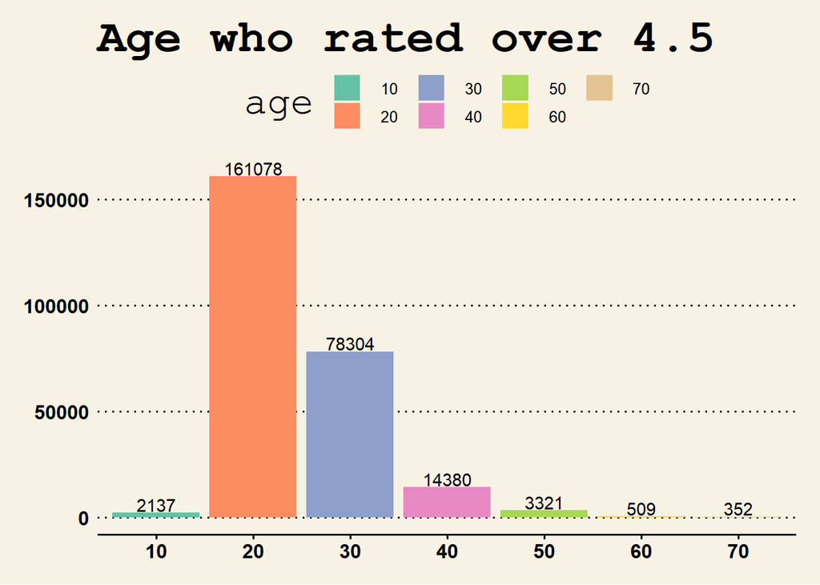

```r
result_final %>% group_by(age) %>% summarise(n = n()) %>%
  ggplot(mapping = aes(x = age, y = n, fill = age)) +
  geom_bar(stat = "identity") + xlab("age") + ylab("") +
  geom_text(aes(label = n), vjust = -0.1) +
  ggtitle("Age who rated over 4.5") +
  scale_fill_brewer(palette = "Set2") +
  ggthemes::theme_wsj()
```

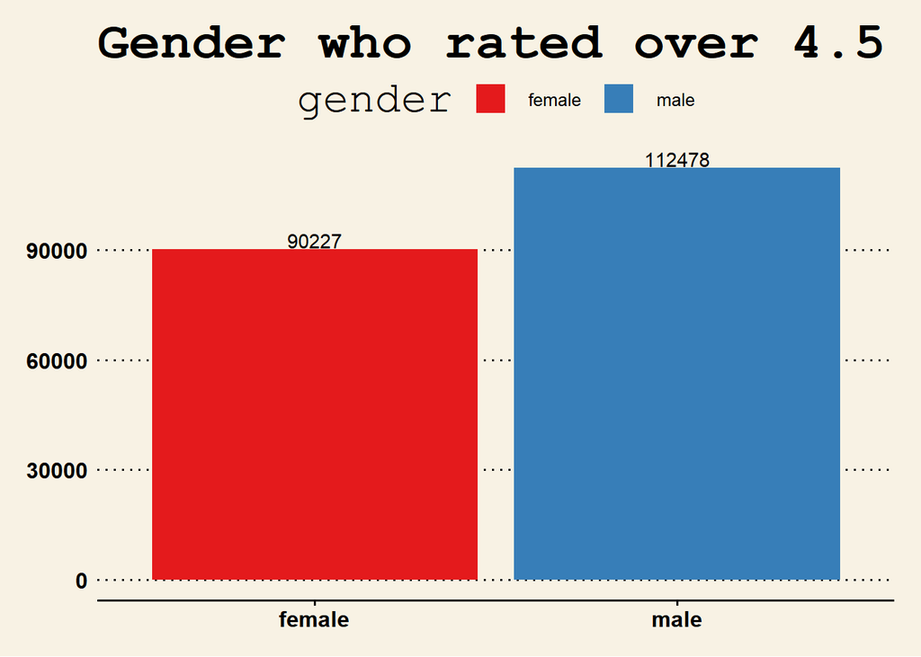

```r
result_final %>% filter(gender != 'not_set') %>% group_by(gender) %>%
  summarise(n = n()) %>%
  ggplot(mapping = aes(x = gender, y = n, fill = gender)) +
  geom_bar(stat = 'identity') + xlab("gender") + ylab("") +
  ggtitle("Gender who rated over 4.5") +
  scale_fill_brewer(palette = 'Set1') +
  geom_text(aes(label = n), vjust = -0.1) +
  ggthemes::theme_wsj()
```

## **3. 텍스트 마이닝 프로세스**

#### 형태소 분석(Parsing)

```r
# 영화 이름
movie <- levels(result$movie_name)

# 최종 담을 데이터
word <- data.frame()

# 영화마다 리뷰 분석한거 한줄로 만들어줌
word_split <- function(data) {
  for(i in 1:length(movie)) {
    cat(i, '번째 진행중! \n')
    # 해당 영화 정보 불러오기
    movie_info <- data %>%
      dplyr::filter(movie_name == movie[i])

    # 해당 영화 리뷰가 없다면 무시하고 진행
    if(is_empty(is.na.data.frame(movie_info))) next

    # 해당 영화 리뷰 원하는 품사만 가져오기
    parse <- pos(movie_info$review, format = 'data.frame') %>% filter(pos %in% c('NNG','VV','VA'))

    # UTF-8 변경이 필요한 경우
    if(is_empty(is.na.data.frame(parse))) {
      parse <- pos(iconv(movie_info$review, to = 'UTF-8'), format = 'data.frame') %>%
        filter(pos %in% c('NNG','VV','VA'))
    }

    tryCatch({
      # 리뷰 한줄로 이어 붙이기
      review <- ''
      for(j in 1:nrow(parse)) {
          review <- str_c(review, parse$token[j], ' ')
      }
    }, error = function(e) cat('-> 에러가 발생했습니다!\n'))

    # 뒤에 단어 완성 시켜주는 파싱
    # ex) 알 -> 알다, 잊 -> 잊다
    parse2 <- r_parser_r(contentVector = review, language = 'ko')

    # 데이터 합치기
    word <- rbind(word, data.frame(movie[i], parse2))
  }
  # 데이터 반환
  return(word)
}

# locale 변경
Sys.setlocale(category = 'LC_ALL', locale = 'korean')
```

```
## [1] "LC_COLLATE=Korean_Korea.949;LC_CTYPE=Korean_Korea.949;LC_MONETARY=Korean_Korea.949;LC_NUMERIC=C;LC_TIME=Korean_Korea.949"
```

```r
# data 불러오기
load(file = 'final.RData')

# 구조 확인
head(word, 20)
```

```
##                                    movie.i.
## 1  내 딸의 남자들 : 아빠가 보고 있다 시즌 3
## 2                   내 친구의 집은 어디인가
## 3                           냉장고를 부탁해
## 4             님과 함께 시즌2 - 최고의 사랑
## 7                                말하는대로
## 9                                  밤도깨비
## 11                                 비밀언니
## 12                               비정상회담
## 13             세상에 나쁜 개는 없다 시즌 1
## 14             세상에 나쁜 개는 없다 시즌 2
## 15             세상에 나쁜 개는 없다 시즌 3
## 16                     신비한 TV 서프라이즈
## 17                                 신화방송
## 18         신화방송 - 신화가 찾은 작은 신화
```

[output cut: 27 more lines]

#### Document Term Matrix 만들기

```r
# 불용어 사전
stopWD <- read.csv(file = 'stopWD.csv', header = TRUE)

# 불용어 사전 확인
stopWD$stopword
```

```
##   [1] 있다     하다     없다     영화     같다     나오다   남다
##   [8] 최고     나다     되다     보다     버리다   좋다     모르다
##  [15] 사람     알다     홍시     감독     샤이론   걷다     가능
##  [22] 가다     가볍다   가지다   가타카   간달프   갈다     갈다
##  [29] 감다     갇히다   공길     관객     관하다   그러다   그렇다
##  [36] 그녀     기자     김영광   깊다     끊다     날다     남자
##  [43] 내다     높다     누구     다단     담다     도트     대하다
##  [50] 때문     락과     루츠     만큼     만들다   많다     맞다
##  [57] 맺다     메이다   무엇     묻다     박보영   받다     배우
##  [64] 배우다   버스터   보이다   보통     블랙     빠트리다 사라지다
##  [71] 산사     소재     시퀀스   심은경   싶다     아무것   않다
##  [78] 아발론   애니     어디     연산군   열리다   여기저기 영화관
##  [85] 오다     윤아     이거     이후     주다     주진우   지다
##  [92] 짜이다   찾다     치다     케빈     트루     편기     포터
##  [99] 해리     호도     재밌다
## 100 Levels: 가능 가다 가볍다 가지다 가타카 간달프 갇히다 갈다 감다 ... 홍시
```

```r
# 말뭉치 만들기
corpus <- word$parse2 %>% VectorSource() %>% VCorpus()

# DTM 만들기
dtm <- DocumentTermMatrix(x = corpus,
                         control = list(removeNumbers = TRUE,
                                        removePunctuation = TRUE,
                                        stopwords = stopWD$stopword,
                                        wordLengths =c(2, Inf)))

colnames(dtm) <- trimws(colnames(dtm))

cat('Before : ', dim(dtm)[1], '행', dim(dtm)[2], '열 차원입니다! \n')
```

```
## Before :  985 행 28360 열 차원입니다!
```

```r
dtm_clean <- removeSparseTerms(dtm, sparse = as.numeric(x = 0.99))

cat('After  : ', dim(dtm_clean)[1], '행', dim(dtm_clean)[2], '열 차원입니다! \n')
```

```
## After  :  985 행 7350 열 차원입니다!
```

```r
m = nrow(word)

dtm_clean$dimnames$Docs <- word$movie.i.[1:m]
dtm_clean$dimnames$Docs <- as.character(dtm_clean$dimnames$Docs)

# DTM 확인
inspect(dtm_clean)
```

```
## <<DocumentTermMatrix (documents: 985, terms: 7350)>>
## Non-/sparse entries: 461185/6778565
## Sparsity           : 94%
## Maximal term length: 6
## Weighting          : term frequency (tf)
## Sample             :
##                               Terms
## Docs                           같다 사람 사랑 생각 없다 영화 있다 재밌다
##   1987                          294  391   15  255  424 1400  695     12
##   그래비티                      181  109   17  123  332 1433  472     28
##   버닝                          385  242   92  351  822 1091  751     22
##   스포트라이트                  192  210   10  161  352 1254  598     20
##   원더                          272  564  211  162  243 1330  634     15
##   이터널 선샤인                 261  338 1658  227  509 1102  618     18
##   조제, 호랑이 그리고 물고기들  209  272 1139  213  516  662  554      4
##   죽은 시인의 사회              228  149   97  214  294 1020  470     14
##   컨택트                        312  148  163  347  484 1440  801     50
##   플로리다 프로젝트             242  182  155  198  426  840  529      8
##                               Terms
## Docs                           좋다 최고
##   1987                          230  101
##   그래비티                      127  188
##   버닝                          149   36
##   스포트라이트                  232   43
##   원더                          486   61
##   이터널 선샤인                 301   85
##   조제, 호랑이 그리고 물고기들  209   33
##   죽은 시인의 사회              159   82
##   컨택트                        185   72
##   플로리다 프로젝트             289   47
```

```r
check <- apply(dtm_clean, 1, sum) %>% as.data.frame() %>% cbind(word$movie.i.)

check %>%
  dplyr::filter(. == 0)
```

```
##   .                     word$movie.i.
## 1 0                        비정상회담
## 2 0                       해부학 교실
## 3 0               소년, 소년을 만나다
## 4 0 라스트 엑소시즘: 잠들지 않는 영혼
```

```r
# DTM에서 한 영화의 단어의 개수가 0인것 제외
load(file = 'dtm_clean.RData')

# DTM 확인
inspect(dtm_clean)
```

```
## <<DocumentTermMatrix (documents: 979, terms: 7285)>>
## Non-/sparse entries: 438651/6693364
## Sparsity           : 94%
## Maximal term length: 6
## Weighting          : term frequency (tf)
## Sample             :
##                               Terms
## Docs                           마음 마지막 사랑 생각 시간 연기 이야기 인생
##   1987                          138    121   15  255   61  148    159   13
##   그래비티                       33     83   17  123   95   42     73   76
##   버닝                           57     87   92  351   69  122    273   59
##   스포트라이트                   70     82   10  161   29   77    129    8
##   이터널 선샤인                 181     46 1658  227  142   44     66   83
##   조제, 호랑이 그리고 물고기들  200    131 1139  213  103    7    129   44
##   주토피아                       58     28  208  182   23    2    103   53
##   죽은 시인의 사회               82    120   97  214   63   35     43  266
##   컨택트                         58     59  163  347  506   46    259  179
##   플로리다 프로젝트             124    126  155  198   38   64     93   54
##                               Terms
## Docs                           장면 재밌다
##   1987                          107     12
##   그래비티                      116     28
##   버닝                          154     22
##   스포트라이트                  187     20
##   이터널 선샤인                  73     18
##   조제, 호랑이 그리고 물고기들   81      4
##   주토피아                       55    148
##   죽은 시인의 사회              138     14
##   컨택트                         73     50
##   플로리다 프로젝트             118      8
```

## **4. 토픽 모델링, LDA**

```r
harmonicMean <- function(logLikelihoods, precision = 2000){
  llMed <- median(logLikelihoods)
  as.double(llMed - log(mean(exp(-mpfr(logLikelihoods,
                                       prec=precision) + llMed))))
}

seqk <- seq(18, 22, 1)
burnin <- 1000
iter <- 1000
keep <- 50

#fitted_many <- lapply(seqk, function(k) LDA(dtm_clean,
#                                            k=k,
#                                            method="Gibbs",
#                                            control=list(burnin=burnin, iter=iter, keep=keep)))

#logLiks_many <- lapply(fitted_many, function(L) L@logLiks[-c(1:(burnin/keep))])

#hm_many <- sapply(logLiks_many, function(h) harmonicMean(h))

# ggplot(data.frame(seqk, hm_many), aes(x = seqk, y = hm_many)) + geom_path(lwd = 1.5) +
#   theme(text = element_text(family = NULL),
#         axis.title.y = element_text(vjust = 1, size = 16),
#         axis.title.x = element_text(vjust = -.5, size = 16),
#         axis.text = element_text(size = 16),
#         plot.title = element_text(size = 20)) +
#   xlab('Number of Topics') +
#   ylab('Harmonic Mean') +
#   ylim(-1400000, -1350000)+
#   ggplot2::annotate('text', x = 9, y = 199000,
#                     label = paste("The optimal number of topics is", seqk[which.max(hm_many)])) +
#   labs(title = "Latent Dirichlet Allocation Analysis", subtitle = "How many distinct topics?")
```

#### 불용어 사전을 만들기 위한 토픽 추출 함수

```r
topic_LDA <- function(data, k) {

  # tf-idf 가중치 계산하기
  term_tfidf = tapply(dtm$v / row_sums(dtm)[dtm$i], dtm$j, mean) * log2(nDocs(dtm) / col_sums(dtm > 0))

  # 인자값
  control_LDA_Gibbs = list(# TopicModelcontrol
    seed          = 100, # 같은 결과 값이 나오게하는 임의의 난수 생성
    verbose       = 0,   # 값이 양의 정수이면 진행 마다 진행률이 나타나고 0이면 나타나지 않는다
    save          = 0,   # 값이 양의 정수이면 진행 마다 모델이 저장되고 0이면 저장되지 않는다
    prefix        = tempfile(), # 중간결과를 저장할 장소
    nstart        = 1,   # 반복이 시작되는 숫자
    best          = TRUE, # TRUE이면 사후최대 가능도를 반환
    keep          = 0,   # 값이 양의 정수이면 진행 마다 로그-가능도가 매 반복마다 저장된다
    estimate.beta = TRUE, # 주제가 정해져있으면 FALSE, 주제가 정해져있지 않으면 TRUE
    # LDAcontrol
    alpha  = 0.1, # 초기 알파 값
    delta  = 0.1, # 초기 델타 값
    iter   = 5000, # Gibbs iteration 반복 횟수
    thin   = 2000, # 중간에 생략 된 Gibbs 반복 횟수, 기본적으로 iter와 같습니다.
    burnin = 0) # 처음에 생략 된 Gibbs 반복 횟수

  # Gibbs방식을 이용한 LDA, k = topic 숫자
  lda_tm = LDA(dtm, k, method = "Gibbs", control = control_LDA_Gibbs)

  # 토픽별 핵심단어 30개 저장하기
  term_topic = terms(lda_tm, 30)

  print(term_topic)
}

load(file = 'lda_tm.RData')

term_topic = terms(lda_tm, 30)

print(term_topic)
```

```
##       Topic 1    Topic 2  Topic 3    Topic 4  Topic 5  Topic 6    Topic 7
##  [1,] "청춘"     "음악"   "사랑"     "역사"   "기억"   "드라마"   "시간"
##  [2,] "선생"     "노래"   "로맨스"   "나라"   "감정"   "시즌"     "인생"
##  [3,] "캡틴"     "행복"   "마음"     "생각"   "생각"   "캐릭터"   "행복"
##  [4,] "생각"     "사랑"   "생각"     "시대"   "슬픔"   "셜록"     "생각"
##  [5,] "인생"     "뮤지컬" "여자"     "국민"   "상처"   "재밌다"   "선택"
##  [6,] "현실"     "인생"   "현실"     "언론"   "자신"   "시작"     "순간"
##  [7,] "자신"     "들다"   "장면"     "연기"   "친구"   "에피소드" "이야기"
##  [8,] "학생"     "장면"   "이야기"   "진실"   "마음"   "시트콤"   "여행"
##  [9,] "시인"     "피아노" "조제"     "감사"   "관계"   "인생"     "하루"
## [10,] "열정"     "마지막" "모습"     "잊다"   "이해"   "왕좌"     "사다"
## [11,] "사다"     "음식"   "인생"     "현실"   "잊다"   "게임"     "타임"
## [12,] "학교"     "감동"   "싫다"     "세상"   "순간"   "장진"     "사랑"
## [13,] "노력"     "연주"   "행복"     "정치"   "표현"   "만화"     "주인공"
## [14,] "세상"     "스토리" "이별"     "사다"   "성장"   "작가"     "자신"
```

[output cut: 109 more lines]

#### LDA 시각화

```r
# 문서별 토픽 번호 저장하기
doc_topic = topics(lda_tm, 1)
doc_topic_df = as.data.frame(doc_topic)
doc_topic_df$name = dtm_clean$dimnames$Docs

# 문서별 토픽 확률값 계산하기
doc_Prob = posterior(lda_tm)$topics
doc_Prob_df = as.data.frame(doc_Prob)

# 최대 확률값 찾기
doc_Prob_df$maxProb = apply(doc_Prob_df, 1, max)


#문서별 토픽번호 및 확률값 추출하기
doc_Prob_df$name = doc_topic_df$name # 확률 데이터 프레임에도 나중에 조인을 위해 영화를 할당해준다

id_topic = merge(doc_topic_df, doc_Prob_df, by = "name")

head(id_topic, 10)
```

```
##                      name doc_topic            1            2            3
## 1                  ...ing         9 0.0007246377 0.0659420290 1.746377e-01
## 2            101 달마시안        20 0.0016949153 0.0016949153 1.694915e-03
## 3               13 고스트        18 0.0015384615 0.0015384615 1.538462e-03
## 4      13구역: 얼티메이텀        20 0.0010101010 0.0010101010 1.010101e-03
## 5  1789 바스티유의 연인들         2 0.0016666667 0.3683333333 1.833333e-02
## 6                    1987         4 0.0276013456 0.0005188437 5.701579e-06
## 7            1번가의 기적        20 0.0033333333 0.0033333333 3.333333e-03
## 8                    2012        14 0.0002739726 0.0002739726 2.739726e-04
## 9                      21        18 0.0594936709 0.0004219409 4.219409e-04
## 10           3:10 투 유마        16 0.0002336449 0.0002336449 2.336449e-04
##               4            5            6            7            8
## 1  0.0007246377 0.0007246377 7.246377e-04 0.0007246377 0.0007246377
## 2  0.0016949153 0.0016949153 1.694915e-03 0.0016949153 0.0016949153
## 3  0.0015384615 0.0169230769 1.538462e-03 0.0015384615 0.0323076923
```

[output cut: 40 more lines]

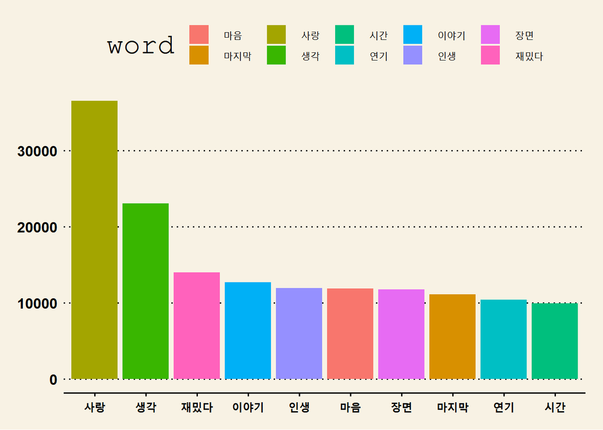

```r
# LDA 시각화
phi = posterior(lda_tm)$term %>% as.matrix

theta = posterior(lda_tm)$topics %>% as.matrix

# vocab는 전체 단어 리스트 입니다.
vocab = colnames(phi)

# 각 단어별 빈도수를 구합니다.
new_dtm = as.matrix(dtm_clean)
freq_matrix = data.frame(word = colnames(new_dtm),
                          Freq = colSums(new_dtm))

freq_matrix %>%
  arrange(desc(Freq)) %>%
  head(10) %>%
  ggplot(mapping = aes(x = reorder(word, -Freq), y = Freq, fill = word)) +
  geom_bar(stat = "identity") +
  ggthemes::theme_wsj()
```

## **5. 추천시스템 및 결론**

#### 추천 시스템

```r
# 랜덤으로 20명 단어 파싱
load(file = 'dtm_clean_userDT.RData')

# 토픽별 단어 data.frame()
load(file = 'lda_DT.RData')

# user별 고빈도 사용단어 추출 후, 토픽 추천함수
# user별  1번 이상 사용단어 logical형태로 추출

# Random으로 1명 무작위 추출
sample_userN <- sample(rownames(dtm_clean_user), 1)
sample_userN
```

```
## [1] "김하현"
```

```r
dtm_clean_user_index <- dtm_clean_user[rownames(dtm_clean_user) == sample_userN,] > 0
a <- dtm_clean_user[rownames(dtm_clean_user) == sample_userN, dtm_clean_user_index]
a
```

```
##        사랑 마음 만나다 죽다 당연하다 마지막 스토리 연기 캐릭터
## 김하현    4    1      1    1        1      1      1    1      1
```

```r
b <- colnames(a)
b
```

```
## [1] "사랑"     "마음"     "만나다"   "죽다"     "당연하다" "마지막"
## [7] "스토리"   "연기"     "캐릭터"
```

```r
# user별 단어 추출 후 lda_dt와 비교해서 토픽 뽑기
max <- Inf
for(j in 1:20){
  sum <- 0
  for(i in 1:7235){
    if(lda_DT[i,j] %in% b){
      sum <- sum + i * 1 / a[lda_DT[i, j] %>% as.character()]
      av <- sum / length(b)
    }
  }
  if(av < max){
    topic <-  colnames(lda_DT)[j]
    max <- av
  }
}

# lda_tm 각 토픽별로 포함되는 영화 추출하기
doc_topic = topics(lda_tm, 1)
doc_topic_df = as.data.frame(doc_topic)
doc_topic_df$name = dtm_clean$dimnames$Docs
doc_topic_df <- doc_topic_df[,c(2,1)]

# 정규표현식 이용하여 나온 토픽의 숫자만 남기기
topic <- topic %>% str_extract(pattern = '\\d+')

# 토픽별 추천 영화 뽑기
Re_MN <- doc_topic_df %>%
  dplyr::filter(doc_topic == topic) %>%
  head(5) %>%
  select(name) %>% as.vector()

cat(sample_userN, '님께 추천해드리는 영화는 아래와 같습니다.\n')
```

```
## 김하현 님께 추천해드리는 영화는 아래와 같습니다.
```

```r
print(Re_MN$name)
```

```
## [1] "마미"                              "로얄 테넌바움"
## [3] "드라큐라"                          "무드 인디고"
## [5] "오직 사랑하는 이들만이 살아남는다"
```